# Session 08: Functions, Pipes and Iteration

326.212 전산통계 및 실습

# Prerequisite

```r
library(tidyverse)
library(magrittr)
```

# Functions

## Why do we use functions?

Functions allow you to automate common tasks in a more powerful and general way than copy-and-pasting.

Advantages over using copy-and-paste:

- You can give a function an evocative name that makes your code easier to understand.
- As requirements change, you only need to update code in one place, instead of many.
- You eliminate the chance of making incidental mistakes when you copy and paste (i.e. updating a variable name in one place, but not in another).

## Components of a function

```r
# name and argument
is_odd <- function(x) {
  "
    Describe your function in here!
  "

  # checking for exception
  if (!is.numeric(x)) {
    stop("The input should be a numeric value")
  }

  if (length(x) != 1) {
    stop("The input should be a numeric value")
  }

  # body
  if (x %% 2 == 0) {
    return(FALSE)
  } else {
    return(TRUE)
  }

}
```

#### Names

- Clear and short name!
- Naming style: `snake_case` vs `camelCase`
- R allows ‘dot’ in names like `dont.do.this`
- Avoid overriding exisiting functions and variables

#### Arguments

Detail arguments should go on the end, and usually should have default values.

```r
# Compute confidence interval around mean using normal approximation
mean_ci <- function(x, conf = 0.95) {
  se <- sd(x) / sqrt(length(x))
  alpha <- 1 - conf
  mean(x) + se * qnorm(c(alpha / 2, 1 - alpha / 2))
}

x <- runif(100)
mean_ci(x)
```

```
## [1] 0.4424035 0.5524252
```

**Do not** put default valued arguments before non-default valued arguments.

```r
# good
no_use_sum <- function(a, b, c = 0) {
  return(a+b+c)
}

# bad
no_use_sum <- function(a, b = 0, c) {
  return(a+b+c)
}
```

Do exception hadling. (Using `try()` and `tryCatch()` would be good choice. We also learned about `safely()`, `possibly()` and `quietly()`.)

```r
is_odd(1)

is_odd("1")

is_odd(c(1,2))
```

#### Body

The body of function is the main part that what you want to do with function will be programmed. Two main techniques - Conditions and Iterations - will be introduced later.

#### Return

The value returned by the function is usually the last statement it evaluates when you don’t specify return of fucntion.

## Writing pipeable functions

Side-effects functions should “invisibly” return the first argument, so that while they’re not printed they can still be used in a pipeline:

```r
show_missings <- function(df) {
  n <- sum(is.na(df))
  cat("Missing values: ", n, "\n", sep = "")

  invisible(df)
}
```

```r
show_missings(mtcars)
```

```
## Missing values: 0
```

```r
mtcars %>%
  show_missings() %>%
  mutate(mpg = ifelse(mpg < 20, NA, mpg)) %>%
  show_missings()
```

```
## Missing values: 0
## Missing values: 18
```

```r
show_missings2 <- function(df) {
  n <- sum(is.na(df))
  cat("Missing values: ", n, "\n", sep = "")

  df
}

mtcars %>%
  show_missings2() %>%
  mutate(mpg = ifelse(mpg < 20, NA, mpg)) %>%
  show_missings2()
```

```
## Missing values: 0
## Missing values: 18
```

```
##     mpg cyl  disp  hp drat    wt  qsec vs am gear carb
## 1  21.0   6 160.0 110 3.90 2.620 16.46  0  1    4    4
## 2  21.0   6 160.0 110 3.90 2.875 17.02  0  1    4    4
## 3  22.8   4 108.0  93 3.85 2.320 18.61  1  1    4    1
## 4  21.4   6 258.0 110 3.08 3.215 19.44  1  0    3    1
## 5    NA   8 360.0 175 3.15 3.440 17.02  0  0    3    2
## 6    NA   6 225.0 105 2.76 3.460 20.22  1  0    3    1
## 7    NA   8 360.0 245 3.21 3.570 15.84  0  0    3    4
## 8  24.4   4 146.7  62 3.69 3.190 20.00  1  0    4    2
## 9  22.8   4 140.8  95 3.92 3.150 22.90  1  0    4    2
## 10   NA   6 167.6 123 3.92 3.440 18.30  1  0    4    4
## 11   NA   6 167.6 123 3.92 3.440 18.90  1  0    4    4
## 12   NA   8 275.8 180 3.07 4.070 17.40  0  0    3    3
## 13   NA   8 275.8 180 3.07 3.730 17.60  0  0    3    3
## 14   NA   8 275.8 180 3.07 3.780 18.00  0  0    3    3
```

[output cut: 18 more lines]

## Environment

```r
f <- function(x) {
  x + y
}

y <- 100

f(10)
```

```
## [1] 110
```

```r
y <- 1000

f(10)
```

```
## [1] 1010
```

```r
x <- 10
y <- 20

f <- function() {
  x <- 100
  y <- 200

  x + y
}

f()
```

```
## [1] 300
```

```r
x
```

```
## [1] 10
```

```r
y
```

```
## [1] 20
```

```r
rm(y)

x <- 10

f <- function() {
  x <- 100
  y <- 200

  x + y
}

f()

y
```

```r
x <- 10

f <- function() {
  # avoid using this allocation(super assignment)
  x <<- 100

  x
}

f()
```

```
## [1] 100
```

```r
x
```

```
## [1] 100
```

## Conditions

`&`, `|`, `&&`, `||`

```r
c(TRUE,FALSE) & TRUE
```

```
## [1]  TRUE FALSE
```

```r
c(TRUE,FALSE) && TRUE
```

```
## [1] TRUE
```

```r
c(TRUE,FALSE) | TRUE
```

```
## [1] TRUE TRUE
```

```r
c(TRUE,FALSE) || TRUE
```

```
## [1] TRUE
```

`all`, `any`

```r
all(c(TRUE,FALSE) & TRUE)
```

```
## [1] FALSE
```

```r
any(c(TRUE,FALSE) & TRUE)
```

```
## [1] TRUE
```

`==`, `identical`

```r
c(1, 3) == c(3, 3)
```

```
## [1] FALSE  TRUE
```

```r
identical(c(1, 3), c(3, 3))
```

```
## [1] FALSE
```

```r
multiple_op_ftn <- function(x, y, op) {
  if (op == 'plus') {
    x + y
  } else if (op == 'minus') {
    x - y
  } else if (op == 'times') {
    x * y
  } else if (op == 'divide') {
    x / y
  } else {
    stop("Unknown op!")
  }
}

multiple_op_ftn(c(2,4), 3, 'minus')
```

```
## [1] -1  1
```

```r
multiple_op_ftn(c(2,4), 3, 'times')
```

```
## [1]  6 12
```

`switch`

```r
multiple_op_ftn <- function(x, y, op) {
  switch(op,
    plus = x + y,
    minus = x - y,
    times = x * y,
    divide = x / y,
    stop("Unknown op!")
  )
}

multiple_op_ftn(c(2,4), 3, 'minus')
```

```
## [1] -1  1
```

```r
multiple_op_ftn(c(2,4), 3, 'times')
```

```
## [1]  6 12
```

`ifelse()`

```r
x <- 10

ifelse(is_odd(x), "I'm odd!", "I'm even...")
```

```
## [1] "I'm even..."
```

```r
ifelse(is_odd(x + 1), "I'm odd!", "I'm even...")
```

```
## [1] "I'm odd!"
```

```r
mtcars %>% mutate(
  cyl = ifelse(
    cyl == 4, "I'm 4", ifelse(
      cyl == 6, "I'm 6", "I'm 8"
    )
  )
)
```

```
##     mpg   cyl  disp  hp drat    wt  qsec vs am gear carb
## 1  21.0 I'm 6 160.0 110 3.90 2.620 16.46  0  1    4    4
## 2  21.0 I'm 6 160.0 110 3.90 2.875 17.02  0  1    4    4
## 3  22.8 I'm 4 108.0  93 3.85 2.320 18.61  1  1    4    1
## 4  21.4 I'm 6 258.0 110 3.08 3.215 19.44  1  0    3    1
## 5  18.7 I'm 8 360.0 175 3.15 3.440 17.02  0  0    3    2
## 6  18.1 I'm 6 225.0 105 2.76 3.460 20.22  1  0    3    1
## 7  14.3 I'm 8 360.0 245 3.21 3.570 15.84  0  0    3    4
## 8  24.4 I'm 4 146.7  62 3.69 3.190 20.00  1  0    4    2
## 9  22.8 I'm 4 140.8  95 3.92 3.150 22.90  1  0    4    2
## 10 19.2 I'm 6 167.6 123 3.92 3.440 18.30  1  0    4    4
## 11 17.8 I'm 6 167.6 123 3.92 3.440 18.90  1  0    4    4
## 12 16.4 I'm 8 275.8 180 3.07 4.070 17.40  0  0    3    3
## 13 17.3 I'm 8 275.8 180 3.07 3.730 17.60  0  0    3    3
## 14 15.2 I'm 8 275.8 180 3.07 3.780 18.00  0  0    3    3
```

[output cut: 18 more lines]

`dplyr::case_when`

```r
mtcars %>% mutate(
  cyl = case_when(
    cyl == 4 ~ "I'm 4",
    cyl == 6 ~ "I'm 6",
    cyl == 8 ~ "I'm 8"
  )
)
```

```
##     mpg   cyl  disp  hp drat    wt  qsec vs am gear carb
## 1  21.0 I'm 6 160.0 110 3.90 2.620 16.46  0  1    4    4
## 2  21.0 I'm 6 160.0 110 3.90 2.875 17.02  0  1    4    4
## 3  22.8 I'm 4 108.0  93 3.85 2.320 18.61  1  1    4    1
## 4  21.4 I'm 6 258.0 110 3.08 3.215 19.44  1  0    3    1
## 5  18.7 I'm 8 360.0 175 3.15 3.440 17.02  0  0    3    2
## 6  18.1 I'm 6 225.0 105 2.76 3.460 20.22  1  0    3    1
## 7  14.3 I'm 8 360.0 245 3.21 3.570 15.84  0  0    3    4
## 8  24.4 I'm 4 146.7  62 3.69 3.190 20.00  1  0    4    2
## 9  22.8 I'm 4 140.8  95 3.92 3.150 22.90  1  0    4    2
## 10 19.2 I'm 6 167.6 123 3.92 3.440 18.30  1  0    4    4
## 11 17.8 I'm 6 167.6 123 3.92 3.440 18.90  1  0    4    4
## 12 16.4 I'm 8 275.8 180 3.07 4.070 17.40  0  0    3    3
## 13 17.3 I'm 8 275.8 180 3.07 3.730 17.60  0  0    3    3
## 14 15.2 I'm 8 275.8 180 3.07 3.780 18.00  0  0    3    3
```

[output cut: 18 more lines]

# Pipes

`T pipe`

```r
1:10 %>% mean()
```

```
## [1] 5.5
```

```r
1:10 %T>% mean()
```

```
##  [1]  1  2  3  4  5  6  7  8  9 10
```

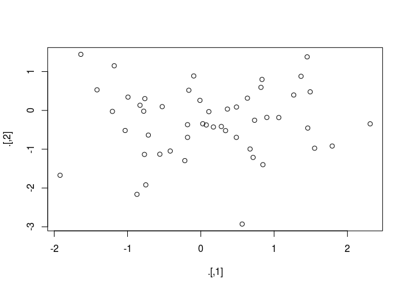

```
##  num [1:50, 1:2] 1.792 0.486 -0.559 -0.769 -0.751 ...
```

```r
rnorm(100) %>%
  matrix(ncol = 2) %T>%
  plot() %>%
  str()
```

`%$%`

```r
mtcars %$%
  cor(disp, mpg)
```

```
## [1] -0.8475514
```

```r
cor(mtcars$disp, mtcars$mpg)
```

```
## [1] -0.8475514
```

`%<>%`

```r
set.seed(1120)

x <- rnorm(10)

(x <- x %>% matrix(ncol = 2))
```

```
##            [,1]       [,2]
## [1,]  0.3805889 -1.2643568
## [2,] -0.9436353 -1.2314873
## [3,] -1.7705009  2.6173065
## [4,]  0.1423112  0.9884666
## [5,] -0.5777802  0.7360332
```

```r
set.seed(1120)

x <- rnorm(10)

(x %<>% matrix(ncol = 2))
```

```
##            [,1]       [,2]
## [1,]  0.3805889 -1.2643568
## [2,] -0.9436353 -1.2314873
## [3,] -1.7705009  2.6173065
## [4,]  0.1423112  0.9884666
## [5,] -0.5777802  0.7360332
```